# Data Visualization with Matplotlib

## 3D Plots

Matplotlib can create 3D visualizations for data that varies in three dimensions. This is useful for showing surfaces, 3D scatter plots, or complex mathematical functions.

### Setting Up 3D Plots

To create 3D plots, we need to import a special toolkit and specify that we want a 3D projection:

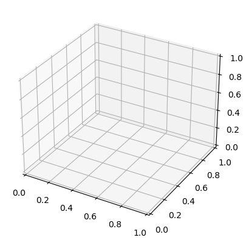

```python
from mpl_toolkits.mplot3d import Axes3D

fig = plt.figure()
ax = fig.add_subplot(111, projection='3d')
plt.show()
```

This creates a 3D axes with x, y, and z dimensions that you can rotate interactively.

### 3D Line Plots

Let's start with a simple 3D line - a helix:

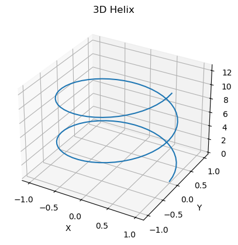

```python
fig = plt.figure()
ax = fig.add_subplot(111, projection='3d')

# Create a helix
t = np.linspace(0, 4*np.pi, 100)
x = np.cos(t)
y = np.sin(t)
z = t

ax.plot(x, y, z)
ax.set_xlabel('X')
ax.set_ylabel('Y')
ax.set_zlabel('Z')
ax.set_title('3D Helix')
plt.show()
```

The 3D plot shows how the line spirals through space. You can rotate this interactively in Jupyter notebooks.

### 3D Scatter Plots

3D scatter plots are useful for visualizing three-dimensional distributions:

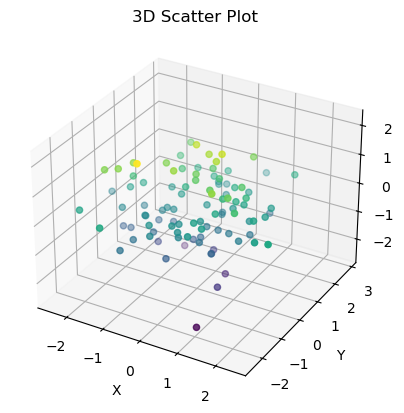

```python
fig = plt.figure()
ax = fig.add_subplot(111, projection='3d')

# Generate random 3D data
n = 100
xs = np.random.normal(0, 1, n)
ys = np.random.normal(0, 1, n)
zs = np.random.normal(0, 1, n)

ax.scatter(xs, ys, zs, c=zs, cmap='viridis')
ax.set_xlabel('X')
ax.set_ylabel('Y')
ax.set_zlabel('Z')
ax.set_title('3D Scatter Plot')
plt.show()
```

The `c=zs` parameter colors points by their z-value, adding an extra dimension of information.

### Surface Plots

Surface plots are perfect for visualizing 2D functions or fitted surfaces. Let's create a 3D surface:

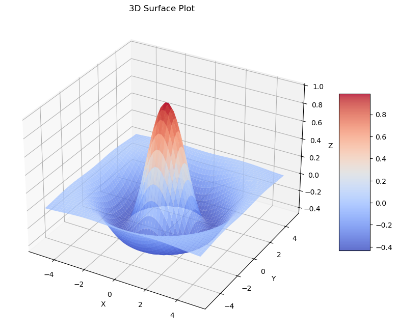

```python
fig = plt.figure(figsize=(10, 8))
ax = fig.add_subplot(111, projection='3d')

# Create grid
x = np.linspace(-5, 5, 50)
y = np.linspace(-5, 5, 50)
X, Y = np.meshgrid(x, y)

# Create a surface function (like a 2D Gaussian)
Z = np.exp(-(X**2 + Y**2)/10) * np.cos(np.sqrt(X**2 + Y**2))

# Plot the surface
surf = ax.plot_surface(X, Y, Z, cmap='coolwarm', alpha=0.8)

ax.set_xlabel('X')
ax.set_ylabel('Y')
ax.set_zlabel('Z')
ax.set_title('3D Surface Plot')

# Add a colorbar
fig.colorbar(surf, shrink=0.5, aspect=5)
plt.show()
```

The `plot_surface()` function creates a smooth surface connecting all the grid points.

### Adjusting 3D View Angle

You can set the viewing angle programmatically:

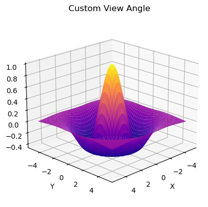

```python
fig = plt.figure()
ax = fig.add_subplot(111, projection='3d')

ax.plot_surface(X, Y, Z, cmap='plasma')
ax.view_init(elev=20, azim=45)  # Elevation and azimuth angles
ax.set_xlabel('X')
ax.set_ylabel('Y')
ax.set_zlabel('Z')
ax.set_title('Custom View Angle')
plt.show()
```

The `view_init()` function sets the elevation (vertical angle) and azimuth (horizontal rotation).

## Sky Projections for Survey Data

Astronomical surveys observe objects across the entire sky. Displaying positions on the celestial sphere requires special projections:

```python
# Generate random star positions across the sky
n_stars = 1000
ra = np.random.uniform(0, 360, n_stars)   # Right Ascension in degrees
dec = np.random.uniform(-90, 90, n_stars)  # Declination in degrees
```

For all-sky projections, we need to convert to radians and adjust the coordinate system:

```python
ra_rad = np.deg2rad(ra - 180)  # Convert to radians and center at RA=180
dec_rad = np.deg2rad(dec)
```

Now create an all-sky map using the Mollweide projection:

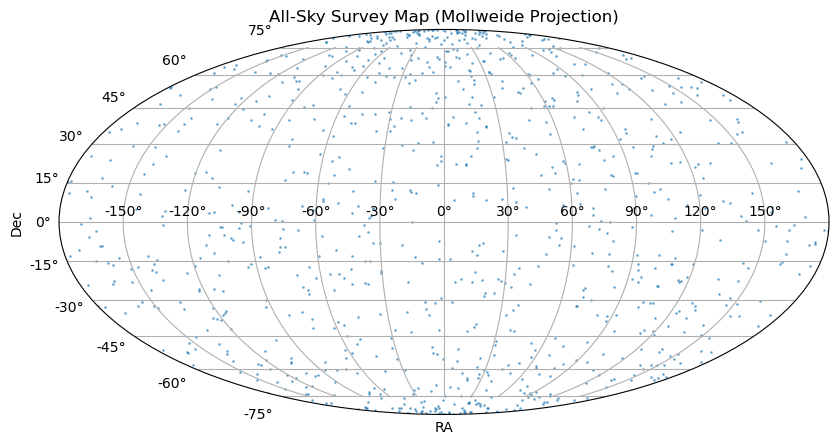

```python
fig = plt.figure(figsize=(10, 5))
ax = fig.add_subplot(111, projection='mollweide')

ax.scatter(ra_rad, dec_rad, s=1, alpha=0.5)
ax.set_xlabel('RA')
ax.set_ylabel('Dec')
ax.grid(True)
plt.title('All-Sky Survey Map (Mollweide Projection)')
plt.show()
```

The `projection='mollweide'` parameter creates an oval-shaped map that shows the entire sky. This is standard for displaying survey data.

## Global Settings with rcParams

Matplotlib's appearance is controlled by rcParams (runtime configuration parameters). You can modify these to change default settings for all your plots.

### Viewing Current Settings

You can see all current settings:

```python
import matplotlib as mpl

# View a specific parameter
print(mpl.rcParams['lines.linewidth'])
print(mpl.rcParams['font.size'])
```

```
1.5
10.0
```

### Modifying rcParams

You can change defaults for your entire session:

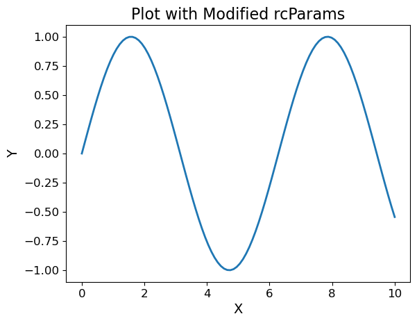

```python
# Change default settings
mpl.rcParams['lines.linewidth'] = 2
mpl.rcParams['lines.markersize'] = 8
mpl.rcParams['font.size'] = 12
mpl.rcParams['axes.labelsize'] = 14
mpl.rcParams['axes.titlesize'] = 16
mpl.rcParams['legend.fontsize'] = 11

# Now all plots will use these defaults
x = np.linspace(0, 10, 100)
plt.plot(x, np.sin(x))
plt.xlabel('X')
plt.ylabel('Y')
plt.title('Plot with Modified rcParams')
plt.show()
```

### Using RC Context Manager

For temporary changes (that only apply within a specific code block), use the context manager:

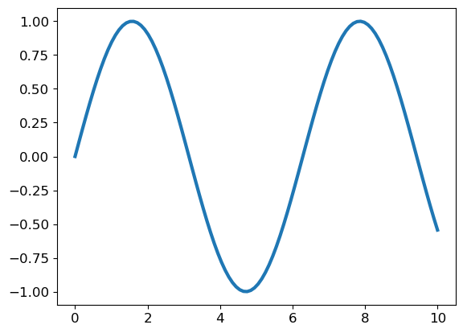

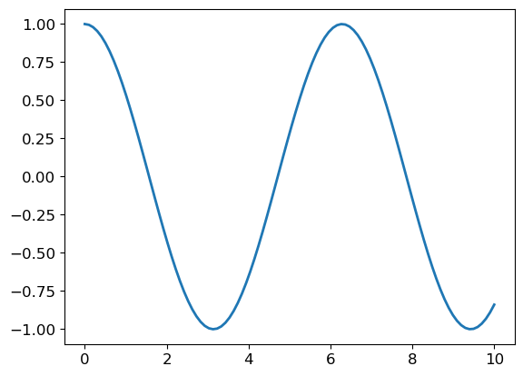

```python
with mpl.rc_context({'lines.linewidth': 3, 'lines.color': 'red'}):
    plt.plot(x, np.sin(x))
    plt.show()

# Outside the context, defaults are restored
plt.plot(x, np.cos(x))
plt.show()
```

## LaTeX Rendering for Publication-Quality Equations

For professional publications, you often need properly formatted mathematical expressions. Matplotlib can use LaTeX to render text.

You can use LaTeX syntax in any text by wrapping it in dollar signs:

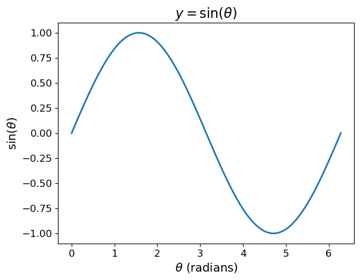

```python
x = np.linspace(0, 2*np.pi, 100)
y = np.sin(x)

plt.plot(x, y)
plt.xlabel(r'$\theta$ (radians)')  # r'' for raw string
plt.ylabel(r'$\sin(\theta)$')
plt.title(r'$y = \sin(\theta)$')
plt.show()
```

The `r` before the string makes it a "raw string" - this tells Python to treat backslashes literally instead of as escape characters. In regular strings, \n means newline, \t means tab, etc. But in LaTeX, backslashes are used for commands like \sin, \theta, \alpha. Raw strings prevent Python from interpreting these backslashes, passing them directly to LaTeX.

### More Complex Equations

You can include complex mathematical expressions:

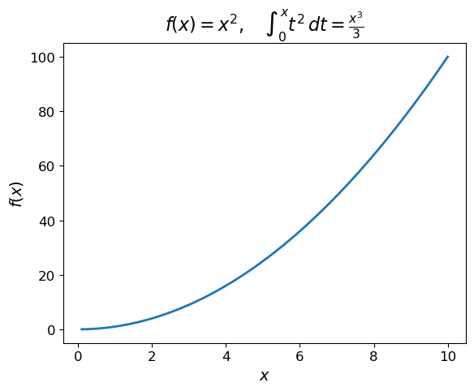

```python
x = np.linspace(0.1, 10, 100)
y = x**2

plt.plot(x, y)
plt.xlabel(r'$x$')
plt.ylabel(r'$f(x)$')
plt.title(r'$f(x) = x^2, \quad \int_0^x t^2\,dt = \frac{x^3}{3}$')
plt.show()
```

LaTeX makes it easy to include Greek letters and mathematical symbols:

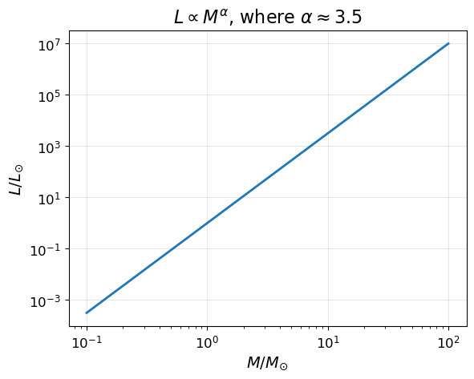

```python
# Mass-luminosity relation
masses = np.logspace(-1, 2, 50)
luminosities = masses**3.5

plt.loglog(masses, luminosities)
plt.xlabel(r'$M/M_{\odot}$')  # Solar mass symbol
plt.ylabel(r'$L/L_{\odot}$')
plt.title(r'$L \propto M^{\alpha}$, where $\alpha \approx 3.5$')
plt.grid(True, alpha=0.3)
plt.show()
```

## DPI and Rasterization for Complex Figures

When creating figures with thousands of points or complex elements, file size and rendering performance become important. DPI (dots per inch) controls the resolution of raster images:

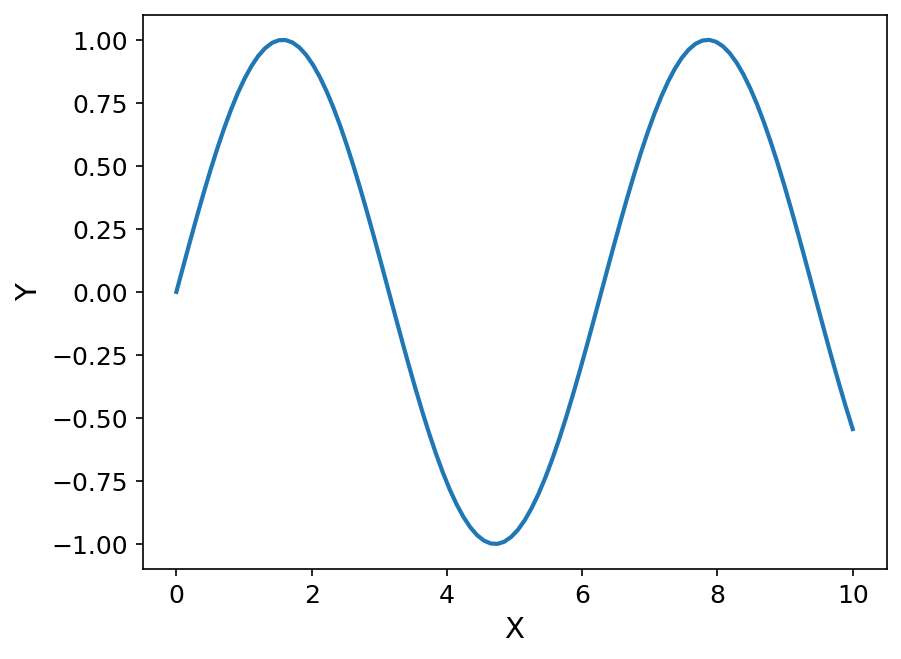

```python
# Create a figure with specific DPI
fig = plt.figure(dpi=150)  # Screen display DPI
ax = fig.add_subplot(111)

x = np.linspace(0, 10, 100)
ax.plot(x, np.sin(x))
ax.set_xlabel('X')
ax.set_ylabel('Y')
plt.show()
```

Different DPI for display vs saving:

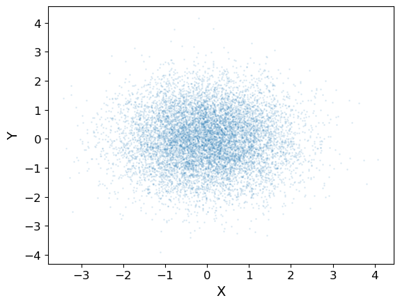

```python
# Display at 100 DPI, save at 300 DPI
fig = plt.figure(dpi=100)
ax = fig.add_subplot(111)

# Create dense scatter plot
n = 10000
x = np.random.normal(0, 1, n)
y = np.random.normal(0, 1, n)
ax.scatter(x, y, s=1, alpha=0.1)
ax.set_xlabel('X')
ax.set_ylabel('Y')

# Save at publication quality
plt.savefig('high_res.png', dpi=300)
plt.savefig('web_res.png', dpi=72)  # Web resolution
plt.show()
```

### Rasterization for Mixed Vector/Raster Figures

When you have plots with many points, pure vector formats (PDF) become huge - and this is a really common mistake that makes publications super silly! You'll end up with that one page in your PDF that takes forever to load and makes everyone's PDF viewer crawl to a halt.

Rasterization converts specific plot elements from vector format (which stores mathematical descriptions of shapes) to raster format (which stores a grid of pixel values). This lets you keep text and axes as crisp vectors while converting data-heavy elements like scatter plots to raster, dramatically reducing file size and preventing those embarrassing slow-loading publication pages:

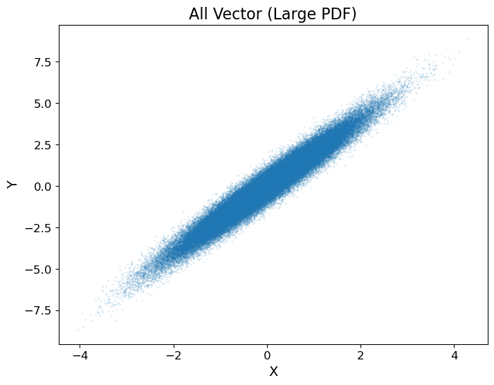

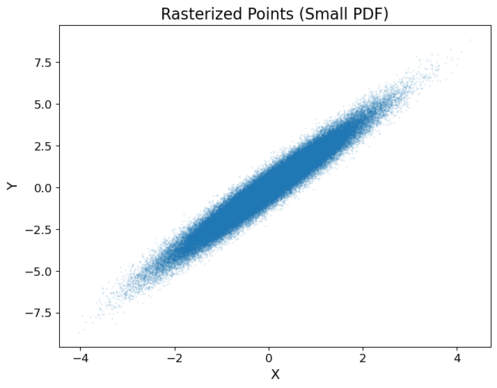

```
Vector-only PDF: 1,556,423 bytes (1.48 MB)
Rasterized PDF: 170,585 bytes (0.16 MB)
Size reduction: 89.0%
```

```python
import os

# Generate many points to see real difference in file sizes
n = 100000  # Increase this for more dramatic differences
x = np.random.normal(0, 1, n)
y = 2*x + np.random.normal(0, 0.5, n)

# First figure: all vector (large file)
fig1 = plt.figure(figsize=(8, 6))
plt.scatter(x, y, s=1, alpha=0.1)
plt.xlabel('X')
plt.ylabel('Y')
plt.title('All Vector (Large PDF)')
plt.savefig('all_vector.pdf', format='pdf')
plt.show()

# Second figure: rasterized scatter (small file)
fig2 = plt.figure(figsize=(8, 6))
plt.scatter(x, y, s=1, alpha=0.1, rasterized=True)
plt.xlabel('X')
plt.ylabel('Y')
plt.title('Rasterized Points (Small PDF)')
plt.savefig('rasterized_points.pdf', format='pdf', dpi=300)
plt.show()

# Check file sizes
vector_size = os.path.getsize('all_vector.pdf')
raster_size = os.path.getsize('rasterized_points.pdf')

print(f"Vector-only PDF: {vector_size:,} bytes ({vector_size/1024/1024:.2f} MB)")
print(f"Rasterized PDF: {raster_size:,} bytes ({raster_size/1024/1024:.2f} MB)")

if vector_size > raster_size:
    print(f"Size reduction: {(vector_size - raster_size)/vector_size*100:.1f}%")
else:
    print("Note: Try increasing n to 500000+ for more dramatic file size differences!")
```

## Interactive Plots with ipywidgets

Static plots are essential for papers, but interactive plots help explore data. Let's use ipywidgets to add controls to our plots:

To create interactive plots, we need to import the widgets library. In a local Jupyter environment:

```
import ipywidgets as widgets
from IPython.display import display
```

Note: Interactive widgets require a local Jupyter environment to function. In the web version of this notebook, you'll see the code structure but won't be able to interact with the sliders.

### Simple Interactive Sine Wave

Let's create a sine wave where we can adjust the frequency:

Here's an example using the decorator syntax for creating interactive plots:

```
@widgets.interact(frequency=(0.1, 5.0, 0.1))
def plot_wave(frequency=1.0):
    plt.figure(figsize=(8, 4))
    t = np.linspace(0, 10, 1000)
    plt.plot(t, np.sin(2*np.pi*frequency*t))
    plt.ylim(-1.5, 1.5)
    plt.xlabel('Time')
    plt.ylabel('Amplitude')
    plt.title(f'Frequency = {frequency:.1f} Hz')
    plt.grid(True, alpha=0.3)
    plt.show()
```

When running locally, this creates a slider that automatically updates the plot as you drag it. The `@widgets.interact` decorator is the simplest way to make any function interactive!

The `@widgets.interact` decorator automatically creates a slider that controls the frequency parameter! The argument `frequency=(0.1, 5.0, 0.1)` defines the slider properties:

- 0.1: minimum value
- 5.0: maximum value
- 0.1: step size (how much the slider increments) This creates a continuous slider from 0.1 to 5.0 Hz with 0.1 Hz increments.

### Interactive Color-Magnitude Diagram

For more sophisticated controls, let's build an interactive CMD explorer:

```python
def plot_cmd(magnitude_limit, color_range):
    # Generate stellar data
    n_stars = 500
    color = np.random.normal(0.8, 0.3, n_stars)
    magnitude = 14 + 3*color + np.random.normal(0, 0.5, n_stars)

    # Apply filters
    mask = (magnitude < magnitude_limit) & (color > color_range[0]) & (color < color_range[1])

    # Plot - always label your axes!
    plt.figure(figsize=(8, 6))
    plt.scatter(color[mask], magnitude[mask], s=5, alpha=0.5)
    plt.xlabel('B-V Color')
    plt.ylabel('V Magnitude')
    plt.title(f'CMD: {mask.sum()} stars shown')
    plt.gca().invert_yaxis()
    plt.xlim(-0.5, 2)
    plt.ylim(20, 10)
    plt.grid(True, alpha=0.3)
    plt.show()
```

We'll use widgets to build sliders that control our CMD plot parameters. The `FloatSlider` creates a single-value slider for magnitude limit, where the `value` parameter sets the initial position at 18, `min` and `max` define the range from 12 to 20, and `description` provides the label text that appears next to the slider. The `FloatRangeSlider` creates a double-ended slider for color range selection, with `value=[0, 1.5]` setting the initial range selection, `min=-0.5` and `max=2` defining the full slider extent, and `description` again providing the label. These widgets will automatically update the plot whenever the user moves the sliders, creating an interactive exploration tool for the color-magnitude diagram.

For more complex interactions, you can create widgets explicitly:

```
# Create widgets
mag_slider = widgets.FloatSlider(value=18, min=12, max=20, description='Mag Limit:')
color_slider = widgets.FloatRangeSlider(value=[0, 1.5], min=-0.5, max=2, description='Color Range:')

# Make it interactive
interactive = widgets.interactive(plot_cmd,
                                 magnitude_limit=mag_slider,
                                 color_range=color_slider)
display(interactive)
```

This approach gives you more control over widget layout and behavior. In a local environment, you'd see sliders for magnitude limit and color range that update the plot interactively.

Now you can explore how different cuts affect your color-magnitude diagram in real-time!

## Customization for Publication-Quality Figures

### Setting Appropriate Font Sizes

Small fonts that look fine on your screen become illegible in publications. Always check your font sizes:

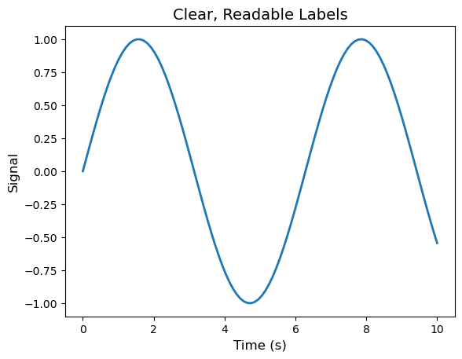

```python
fig, ax = plt.subplots()

x = np.linspace(0, 10, 100)
ax.plot(x, np.sin(x))

# Always label your axes with appropriate font sizes!
ax.set_xlabel('Time (s)', fontsize=12)
ax.set_ylabel('Signal', fontsize=12)
ax.set_title('Clear, Readable Labels', fontsize=14)
ax.tick_params(labelsize=10)
plt.show()
```

A good rule: when your figure is printed at its final size, the smallest text should be at least 8 points.

### Saving Figures in the Right Format

Different formats serve different purposes:

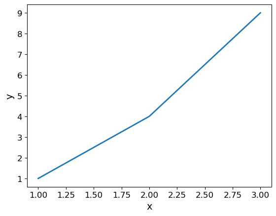

```python
fig, ax = plt.subplots()
ax.plot([1, 2, 3], [1, 4, 9])
ax.set_xlabel('x')  # Never forget axis labels!
ax.set_ylabel('y')

# For journal papers - use vector format
plt.savefig('figure.pdf')

# For presentations or web - use raster format
plt.savefig('figure.png', dpi=300)  # dpi = dots per inch

plt.show()  # Display after saving
```

Vector formats (PDF, EPS) remain sharp at any zoom level - perfect for line plots. Raster formats (PNG, JPG) are better for complex images. Use `dpi=300` for publication quality. Also always rasterize your plot when you have many data points in a scatter plot.

To remove extra whitespace:

```python
plt.savefig('figure.pdf', bbox_inches='tight')
```

```
None
```

### Using Colorblind-Friendly Colors

About 8% of men and 0.5% of women have color vision deficiency. Use colors that everyone can distinguish:

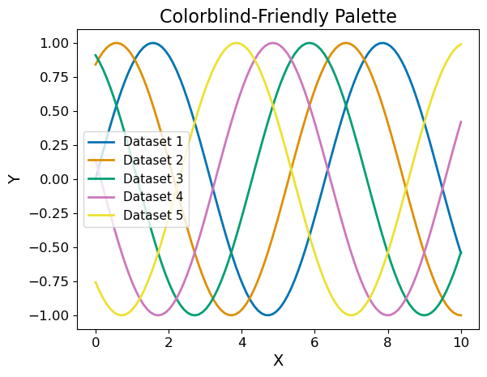

```python
# Define a colorblind-friendly palette
colors = ['#0173B2',  # Blue
          '#DE8F05',  # Orange
          '#029E73',  # Green
          '#CC78BC',  # Light purple
          '#ECE133']  # Yellow

x = np.linspace(0, 10, 100)
for i, color in enumerate(colors):
    plt.plot(x, np.sin(x + i), color=color, label=f'Dataset {i+1}')

plt.legend()
plt.xlabel('X')  # Always label axes!
plt.ylabel('Y')
plt.title('Colorblind-Friendly Palette')
plt.show()
```

Avoid red-green combinations. Blue and orange are generally safe choices.

## Summary

### Key Concepts

In this lecture, you've learned:

- **Basic plotting fundamentals**: How line plots, scatter plots, and histograms form the foundation of all data visualization in astronomy
- **2D visualization techniques**: How to display images, create density plots, and use contours to reveal structure in complex astronomical datasets
- **3D visualization capabilities**: When and how to use 3D plots effectively for surfaces, scatter plots, and multi-dimensional data exploration
- **The object-oriented interface**: Why figures and axes give you precise control over complex multi-panel figures essential for publications
- **Professional customization**: How rcParams, LaTeX rendering, and careful styling transform rough plots into publication-quality figures

### What You Can Now Do

After working through this material, you should be able to:

- Create any standard astronomical plot: light curves, color-magnitude diagrams, finding charts, and spectra
- Display CCD images with appropriate scaling and colormaps to reveal both bright stars and faint structure
- Build complex multi-panel figures comparing different datasets or showing multiple views of the same data
- Add professional elements like error bars, legends, colorbars, and properly formatted axis labels
- Save figures at the correct resolution and format for journals, posters, or presentations

### Practice Suggestions

To solidify these concepts:

1. Take real astronomical data and create a publication-quality figure with proper labels and scaling
2. Recreate a figure from a recent astronomy paper, matching the style and layout as closely as possible
3. Build an interactive widget to explore how changing parameters affects your plots in real-time (when running in a local Jupyter environment)

### Looking Ahead

Next lecture, we'll dive into **LLM API Basics**, learning how to programmatically interact with Large Language Models. The visualization skills you've developed today will be essential for displaying results from automated analyses and creating figures that communicate complex AI-assisted findings. You'll use these plotting techniques throughout the course to visualize everything in you astronomical analysis.